# Curva de Phillips

### A Curva de Phillips

A Curva de Phillips é uma representação gráfica da relação de curto prazo entre inflação e desemprego.

De acordo com Phillips (1958), existe uma relação negativa entre a taxa de desemprego e a taxa de inflação. Isso implica que períodos com desemprego elevado tendem a apresentar um nível menor de inflação.

Phillips encontrou estes resultados para a economia inglesa, entre 1861 e 1957. Samuelson & Solow (1960) também reportam uma correlação negativa entre inflação e desemprego para a economia dos Estados Unidos. Denotaram esta relação de Curva de Phillips, em reconhecimento ao trabalho de Alban William Housego Phillips.

Em 2001, George Akerlof, no discurso de recebimento do Prêmio Nobel, afirmou que “[P]robably the single most important macroeconomic relationship is the Phillips Curve.”

### Construindo o Banco de Dados

```r
# Libraries
library(GetBCBData)
library(tidyverse)
```

Em primeiro lugar, é necessário construir o banco de dados. Note que precisamos das séries históricas da taxa de inflação e da taxa de desemprego.

```r
INF <- gbcbd_get_series(id = c(433),
                        first.date= '2012-03-01',
                        last.date = '2022-06-01',
                        format.data = "long", be.quiet = FALSE)[ ,1:2] %>%
    rename( . ,
            mes = ref.date,
            inf = value)

DES <- gbcbd_get_series(id = c(24369),
                        first.date= '2012-03-01',
                        last.date = '2022-06-01',
                        format.data = "long", be.quiet = FALSE)[ ,1:2] %>%
    rename( . ,
            mes = ref.date,
            des = value)


## Banco de Dados
Phillips <- full_join(INF, DES,
                      by = "mes") %>%
    transform( . ,
               inf = inf/100,
               des = des/100)
```

É sempre interessante observar os dados diretamente.

```r
head(Phillips)
```

```
##          mes    inf   des
## 1 2012-03-01 0.0021 0.080
## 2 2012-04-01 0.0064 0.078
## 3 2012-05-01 0.0036 0.077
## 4 2012-06-01 0.0008 0.076
## 5 2012-07-01 0.0043 0.075
## 6 2012-08-01 0.0041 0.074
```

```r
tail(Phillips)
```

```
##            mes    inf   des
## 119 2022-01-01 0.0054 0.112
## 120 2022-02-01 0.0101 0.112
## 121 2022-03-01 0.0162 0.111
## 122 2022-04-01 0.0106 0.105
## 123 2022-05-01 0.0047 0.098
## 124 2022-06-01 0.0067 0.093
```

### Visualização Gráfica

Uma ferramenta importante na análise de dados (e em economia, particularmente) é a visualização gráfica. O gráfico de uma série histórica, por exemplo, pode oferecer insights muito relevantes para análise econoômica.

Portanto, é sempre conveniente (e recomendado) que se apresente ilustrações gráficas adequadas.

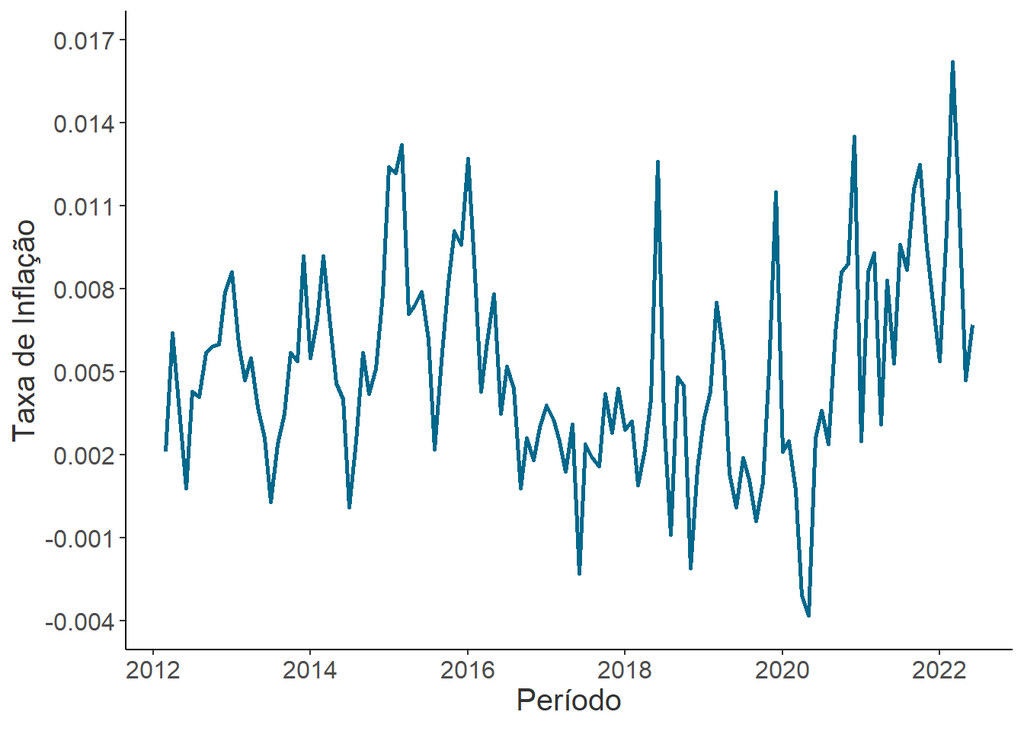

```r
ggplot(data = Phillips,
       aes(x = mes, y = inf)) +
    geom_line( color = "deepskyblue4", size = 1 ) +
    theme_classic() +
    scale_y_continuous(breaks = seq(-0.0040, 0.0170, by = .003), limits = c(-0.004, 0.0170)) +
    xlab("Período") + ylab("Taxa de Inflação") +
    theme(axis.title.x = element_text(colour = "grey20"),
          axis.title.y = element_text(colour = "grey20")) +
    theme( text = element_text( size = 15),
           axis.title.x = element_text(margin = margin(t = 2, r = 2, b = 2, l = 5))) +
    theme(legend.position = "none", legend.title = element_blank())
```

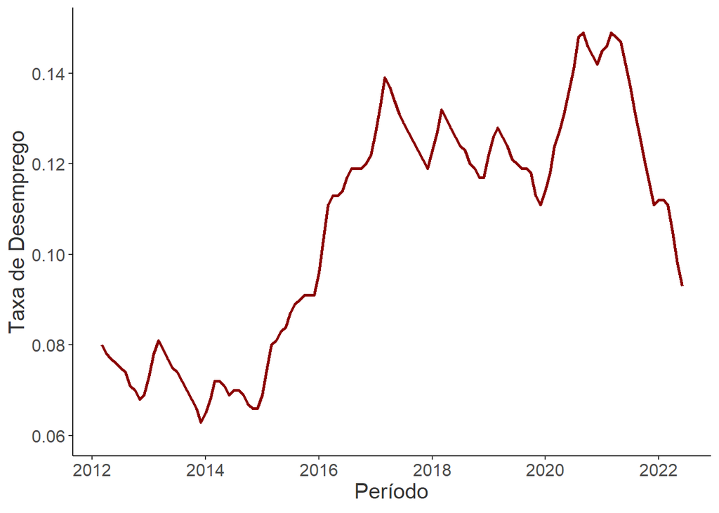

```r
ggplot(data = Phillips,
       aes(x = mes, y = des)) +
    geom_line( color = "darkred", size = 1 ) +
    theme_classic() +
    scale_y_continuous(breaks = seq(0.06, 0.15, by = 0.02), limits = c(0.06, 0.15)) +
    xlab("Período") + ylab("Taxa de Desemprego") +
    theme(axis.title.x = element_text(colour = "grey20"),
          axis.title.y = element_text(colour = "grey20")) +
    theme( text = element_text( size = 15),
           axis.title.x = element_text(margin = margin(t = 2, r = 2, b = 2, l = 5))) +
    theme(legend.position = "none", legend.title = element_blank())
```

### Estimando a Curva de Phillips

Finalmente, o exercício empírico de estimar a relação entre inflação e desemprego. A rigor, a Curva de Phillips é dada pela seguinte especificação
$$\pi_{t} - \pi_{t-1} =
\pi_{t}^{e} + (\mu + z) - \alpha u_{t}$$
em que $\pi_{t}$, $\pi_{t}^{e}$ e $u_{t}$ denotam inflação, inflação esperada, e taxa de desemprego no período $t$, respectivamente. Os termos $\mu$ e $z$ referem-se a parâmetros constantes da curva de oferta agregada.

Por simplificação, neste exercício, assuma que a expectativa de inflação é nula, ou seja, $\pi_{t}^{e} = 0$. Então, temos
$$\pi_{t} -
\pi_{t-1} = (\mu + z) - \alpha u_{t}$$
a relação negativa entre inflação e desemprego encontrada por Phillips. Considere esta versão simples.

Especificamente, vamos estimar uma relação linear entre inflação e desemprego, em que a inflação é a variável dependente. O modelo empírico é dado por
$$\text{inf}_{t} = \beta_{0} +
\beta_{1} \times \text{des}_{t} + \varepsilon_{t}$$

```r
phillips.curve <- lm(inf ~ des, data = Phillips)

summary(phillips.curve)
```

```
##
## Call:
## lm(formula = inf ~ des, data = Phillips)
##
## Residuals:
##        Min         1Q     Median         3Q        Max
## -0.0083473 -0.0022453 -0.0005543  0.0022668  0.0112069
##
## Coefficients:
##              Estimate Std. Error t value Pr(>|t|)
## (Intercept)  0.007468   0.001384   5.397 3.39e-07 ***
## des         -0.022293   0.012651  -1.762   0.0805 .
## ---
## Signif. codes:  0 '***' 0.001 '**' 0.01 '*' 0.05 '.' 0.1 ' ' 1
##
## Residual standard error: 0.003707 on 122 degrees of freedom
## Multiple R-squared:  0.02482,    Adjusted R-squared:  0.01683
## F-statistic: 3.105 on 1 and 122 DF,  p-value: 0.08054
```

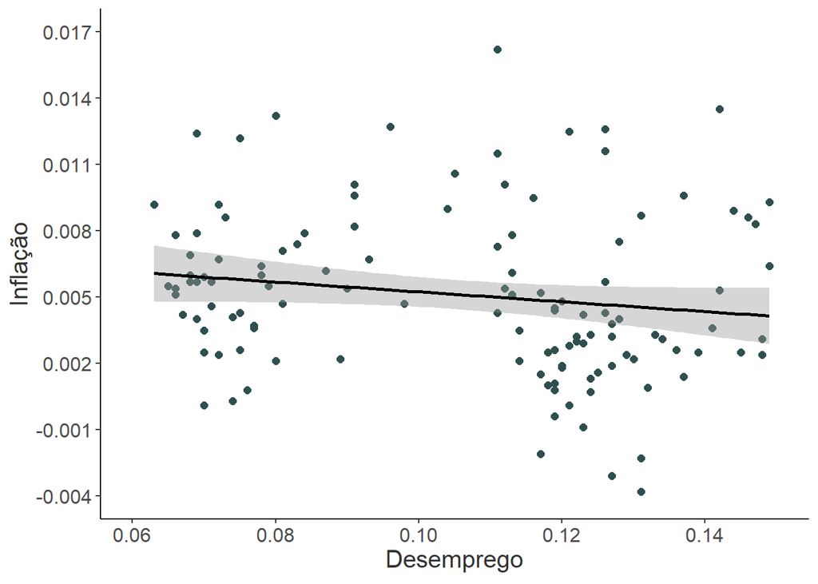

```r
ggplot(data = Phillips,
       aes(x = des, y = inf)) +
    geom_point( color = "darkslategray", shape = 16, size = 2) +
    theme_classic() +
    geom_smooth(method = 'lm',formula = y ~ x, color = 'black') +
    scale_y_continuous(breaks = seq(-0.0040, 0.0170, by = .003), limits = c(-0.004, 0.0170)) +
    scale_x_continuous(breaks = seq(0.06, 0.15, by = 0.02), limits = c(0.06, 0.15)) +
    xlab("Desemprego") + ylab("Inflação") +
    theme(axis.title.x = element_text(colour = "grey20"),
          axis.title.y = element_text(colour = "grey20")) +
    theme( text = element_text( size = 15),
           axis.title.x = element_text(margin = margin(t = 2, r = 2, b = 2, l = 5))) +
    theme(legend.position = "none", legend.title = element_blank())
```

### Importante

Este é um exercício simples, com uma especificação para a Curva de Phillips bastante simplificada. Há muita coisa interessante acerca desta relação que requer a atenção. Divirtam-se.